# index_RNN

DELE ST1504 CA1 Part B: Recurrent Neural Network

Name: Lee Hong Yi  
Admin No: 2223010  
Class: DAAA/FT/2B/07

**Objective:**  
To develop a model that predicts the next word in a sequence, using a provided dataset. The model should be able to generate creative and meaningful sequences of text based on input word sequences.

**Background Information:**  
Language is a dynamic and complex system, with words often following predictable patterns. By understanding these patterns, a model can be trained to predict the next word in a sequence. This capability is fundamental in various applications such as text completion, chatbots, and creative writing aids. The objective is to create a model that not only predicts the next word but also can generate diverse and contextually appropriate continuations.

**Additional Information:**  
The model should be capable of generating different outputs for the same input sequence.  
The output should be evaluated for creativity and meaningfulness.  
A comparison between the outputs of a trained model and an untrained model will highlight the importance of training in language models.

**Output Variable:**  
The word that follows a given sequence of words, with the ability to generate extended sequences (e.g., ten words) based on repeated predictions.

Importing Libraries

```python
import nltk
import string
import numpy as np
import pandas as pd
import seaborn as sns
import matplotlib.pyplot as plt
from collections import  Counter
from nltk.corpus import stopwords
import matplotlib.gridspec as gridspec
from sklearn.feature_extraction.text import CountVectorizer

import tensorflow as tf
from keras_nlp.metrics import Perplexity
from tensorflow.keras.models import Sequential
from nltk.translate.bleu_score import sentence_bleu
from tensorflow.keras.callbacks import EarlyStopping
from tensorflow.keras.preprocessing.text import Tokenizer
from tensorflow.keras.utils import pad_sequences, to_categorical
from tensorflow.keras.layers import Embedding, LSTM, Dense, Dropout, SimpleRNN, GRU, Flatten, Bidirectional

sns.set_style("darkgrid");
nltk.download('stopwords')
```

```
True
```

```python
gpus = tf.config.experimental.list_physical_devices('GPU')
for gpu in gpus:
    print(tf.config.experimental.get_device_details(gpu))
    tf.config.experimental.set_memory_growth(gpu, True)
print(f"There are {len(gpus)} GPU(s) present.")
```

```
{'device_name': 'NVIDIA GeForce RTX 3060', 'compute_capability': (8, 6)}
There are 1 GPU(s) present.
```

Importing Data

```python
data = pd.read_csv("./train.csv")
print(data)

print(f'There are {len(data)} quotes in this dataset.')
```

```
                                                Quotes
0    Embrace the beauty of every sunrise; it's a fr...
1    Embrace challenges; they are the stepping ston...
2    Embrace the rhythm of life and let it dance th...
3    Embrace kindness, for it has the power to chan...
4    Embrace the journey, for it leads to the desti...
..                                                 ...
995  With an open heart, welcome the opportunities ...
996  This morning, let your laughter be the music t...
997  In the serenity of this morning, find the powe...
998  This morning, let your actions be a testament ...
999  With each sunrise, this morning offers the pro...

[1000 rows x 1 columns]
There are 1000 quotes in this dataset.
```

Creating Functions

Exploratory Data Analysis (EDA)

```python
data.describe(include="all")
```

|  | Quotes |
| --- | --- |
| count | 1000 |
| unique | 890 |
| top | Radiate acceptance, and find peace in embracin... |
| freq | 5 |

From the above, we can see that there are some quotes which are repeated within the dataset. We shall take note of this, and determine what to do with it later.

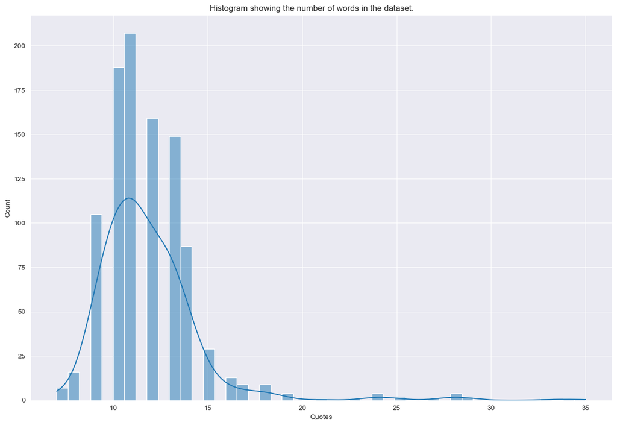

```python
fig = plt.figure(figsize = (15,10))
plt.suptitle("Histogram showing the number of words in the dataset.", y = 0.90)
sns.histplot(data["Quotes"].str.split().map(lambda x: len(x)), kde = True)
plt.show()
```

From the above graph, we can see that the data appears to have a higher frequency at around 10 to 15 quotes, with a significant drop in frequency above 20. It seems to also be right-skewed, owing to the long tail on the right.

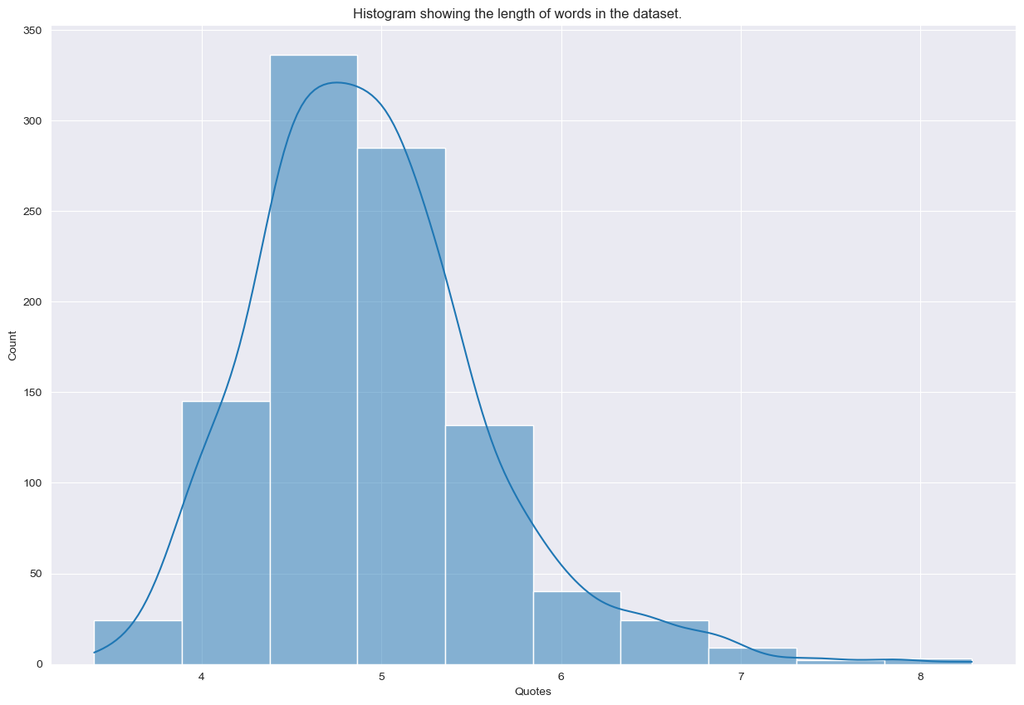

```python
fig = plt.figure(figsize = (15,10))
plt.suptitle("Histogram showing the length of words in the dataset.", y = 0.90)
sns.histplot(data["Quotes"].str.split().apply(lambda x : [len(i) for i in x]).map(lambda x: np.mean(x)), kde = True, bins = 10)
plt.show()
```

The average word length ranges between 3 to 9 with 5 being the most common length. Does it mean that people are using really short words in the dataset?

One reason why this may not be true is stopwords. Stopwords are the words that are most commonly used in any language such as “the”,” a”,” an” etc. As such words are usually short in length, these words may have caused the distribution to appear as such.

Analyzing the amount and the types of stopwords can give us some good insights into the data.

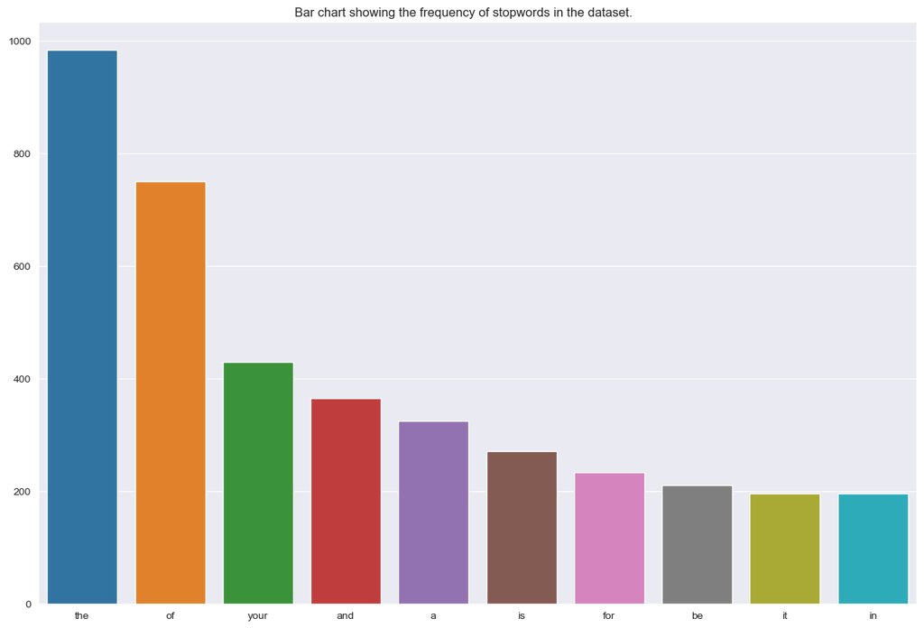

```python
stop=set(stopwords.words('english'))

new= data["Quotes"].str.split()
new=new.values.tolist()
corpus=[word for i in new for word in i]
from collections import defaultdict
dic=defaultdict(int)
for word in corpus:
    if word in stop:
        dic[word]+=1

top=sorted(dic.items(), key=lambda x:x[1],reverse=True)[:10]
x,y=zip(*top)
fig = plt.figure(figsize = (15,10))
plt.suptitle("Bar chart showing the frequency of stopwords in the dataset.", y = 0.90)
sns.barplot(x = list(x), y = list(y))

plt.show()
```

From the above graph, we can see that the words "the", "of", "your", "and", and "a" appear quite frequently.

Now that we know which "stopwords" appear the most frequently, we can now check out which less frequently used words are used frequently in the dataset.

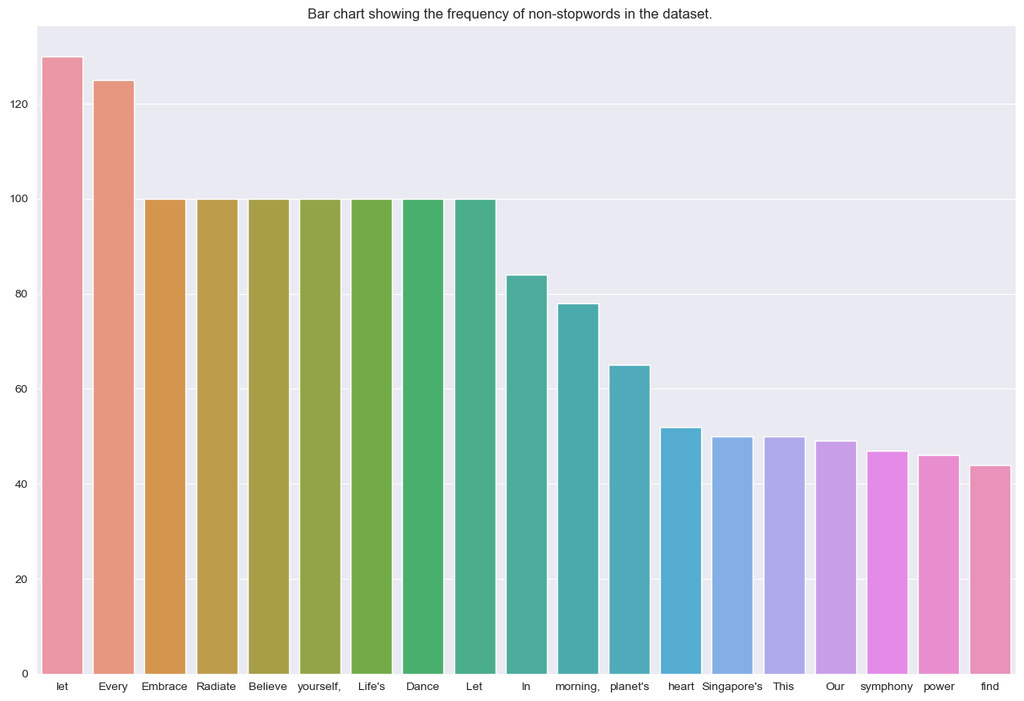

```python
stop = set(stopwords.words('english'))

new = data["Quotes"].str.split()
new = new.values.tolist()
corpus = [word for i in new for word in i]
counter = Counter(corpus)
most = counter.most_common()
x, y = [], []
for word, count in most[:40]:
    if (word not in stop):
        x.append(word)
        y.append(count)

fig = plt.figure(figsize=(15, 10))
plt.suptitle("Bar chart showing the frequency of non-stopwords in the dataset.", y = 0.90)
sns.barplot(x=x, y=y)
plt.show()
```

From the above, we can see that the words "let", "Every" are the most popular by far, with the words "Embrace", "Radiate", "Believe", "yourself,", "Life's", "Dance", and "Let" all typing for 3rd place. The dataset seems to be very inspirational, and is something we can take note of when evaluating the results later.

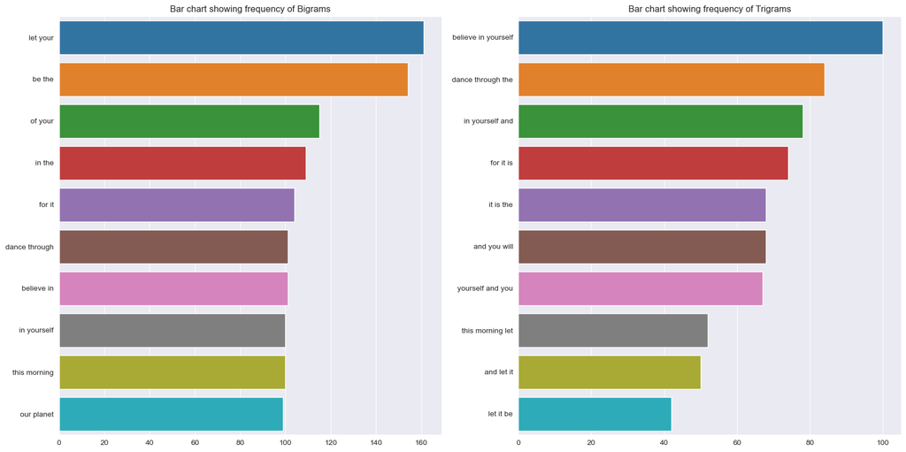

```python
def plot_top_ngrams_barchart(text, axs, n=2):
    stop = set(stopwords.words('english'))

    new = text.str.split()
    new = new.values.tolist()
    corpus = [word for i in new for word in i]

    def _get_top_ngram(corpus, n=None):
        vec = CountVectorizer(ngram_range=(n, n)).fit(corpus)
        bag_of_words = vec.transform(corpus)
        sum_words = bag_of_words.sum(axis=0)
        words_freq = [(word, sum_words[0, idx])
                      for word, idx in vec.vocabulary_.items()]
        words_freq = sorted(words_freq, key=lambda x: x[1], reverse=True)
        return words_freq[:10]

    top_n_bigrams = _get_top_ngram(text, n)[:10]
    x, y = map(list, zip(*top_n_bigrams))
    ax = sns.barplot(x=y, y=x, ax = axs)
    return ax


fig, ax = plt.subplots(1,2, figsize = (20, 10))
plot_top_ngrams_barchart(data['Quotes'], ax[0], 2)
ax[0].set_title("Bar chart showing frequency of Bigrams")
plot_top_ngrams_barchart(data['Quotes'], ax[1], 3)
ax[1].set_title("Bar chart showing frequency of Trigrams")

plt.show()
```

Data Preparation

Data Cleaning

To clean the data, and get it ready for the model, we shall first remove all forms of punctuation, such as "!",":", etc. To do this, we shall use the `string` library in python.

```python
string.punctuation
```

```
'!"#$%&\'()*+,-./:;<=>?@[\\]^_`{|}~'
```

We shall remove these punctuations from the input text, as they are not needed for our desired output.

```python
def remove_punctuation(text):
    no_punct=[words for words in text if words not in string.punctuation]
    words_wo_punct=''.join(no_punct)
    return words_wo_punct
data['Quotes_nopunct']=data['Quotes'].apply(lambda x: remove_punctuation(x))
display(data.head(10))
data["Quotes"] = data["Quotes_nopunct"]
data = data.drop(columns = ["Quotes_nopunct"])
```

|  | Quotes | Quotes_nopunct |
| --- | --- | --- |
| 0 | Embrace the beauty of every sunrise; it's a fr... | Embrace the beauty of every sunrise its a fres... |
| 1 | Embrace challenges; they are the stepping ston... | Embrace challenges they are the stepping stone... |
| 2 | Embrace the rhythm of life and let it dance th... | Embrace the rhythm of life and let it dance th... |
| 3 | Embrace kindness, for it has the power to chan... | Embrace kindness for it has the power to chang... |
| 4 | Embrace the journey, for it leads to the desti... | Embrace the journey for it leads to the destin... |
| 5 | Embrace your uniqueness, for it is the fingerp... | Embrace your uniqueness for it is the fingerpr... |
| 6 | Embrace the present moment, for it is the only... | Embrace the present moment for it is the only ... |
| 7 | Embrace your fears, for they hold the key to u... | Embrace your fears for they hold the key to un... |
| 8 | Embrace gratitude, and watch how it multiplies... | Embrace gratitude and watch how it multiplies ... |
| 9 | Embrace the rain, for it nourishes the seeds o... | Embrace the rain for it nourishes the seeds of... |

```python
data["QuotesLowered"] = data["Quotes"].apply(lambda x: x.lower())
display(data.head(10))
data["Quotes"] = data["QuotesLowered"]
data = data.drop(columns = ["QuotesLowered"])
```

|  | Quotes | QuotesLowered |
| --- | --- | --- |
| 0 | Embrace the beauty of every sunrise its a fres... | embrace the beauty of every sunrise its a fres... |
| 1 | Embrace challenges they are the stepping stone... | embrace challenges they are the stepping stone... |
| 2 | Embrace the rhythm of life and let it dance th... | embrace the rhythm of life and let it dance th... |
| 3 | Embrace kindness for it has the power to chang... | embrace kindness for it has the power to chang... |
| 4 | Embrace the journey for it leads to the destin... | embrace the journey for it leads to the destin... |
| 5 | Embrace your uniqueness for it is the fingerpr... | embrace your uniqueness for it is the fingerpr... |
| 6 | Embrace the present moment for it is the only ... | embrace the present moment for it is the only ... |
| 7 | Embrace your fears for they hold the key to un... | embrace your fears for they hold the key to un... |
| 8 | Embrace gratitude and watch how it multiplies ... | embrace gratitude and watch how it multiplies ... |
| 9 | Embrace the rain for it nourishes the seeds of... | embrace the rain for it nourishes the seeds of... |

We shall also remove the duplicates, as they can influence the prevalance of some quotes, and promote their usage, which may not be accurate.

```python
final_data = list(set(data["Quotes"].values))

print(f"Number of Duplicates: {len(data['Quotes'].values) - len(final_data)}")
print(f"Length of final data: {len(final_data)}")
```

```
Number of Duplicates: 110
Length of final data: 890
```

Tokenization

Now, we shall use Word Tokenization to tokenize our words, so that it can be given to the model for training. Word Tokenization splits a piece of text into invidiual words based on a certain delimiter, and generated different word-level tokens based on the delimiter. However, one issue that can arise from Word Tokenization is dealing with Out Of Vocabulary (OOV) words, which are words that are not present in the training dataset. We shall prepare for this in advance by adding a error handler into the Tokenzier, namely an "Unknown Token <UNK>". If the model encounters a OOV word, it maps it to the <UNK> index.

One other way that is usually used to solve this error would be to use Character Tokenization. However, it adds an additional layer of complexity to the task, and is unnessecary for this task, hence, we shall not use it.

```python
tokenizer = Tokenizer(oov_token='<UNK>')
tokenizer.fit_on_texts(final_data)
print(tokenizer.word_index)
```

```
{'<UNK>': 1, 'the': 2, 'of': 3, 'your': 4, 'and': 5, 'a': 6, 'is': 7, 'in': 8, 'for': 9, 'let': 10, 'to': 11, 'it': 12, 'be': 13, 'every': 14, 'our': 15, 'you': 16, 'that': 17, 'embrace': 18, 'lifes': 19, 'this': 20, 'are': 21, 'morning': 22, 'with': 23, 'radiate': 24, 'heart': 25, 'believe': 26, 'd…
```

Since the Keras tokenizer already numerically encodes the data for us, we do not need to use more traditional methods, such as Bag-of-Words and TF-IDF to do so.

From the above, we can also see which word is assigned to which index, with the index "0" being reserved for padding, and 1 given for the OOV words.

```python
for i in range(5):
    print(final_data[i])
    print(f"{tokenizer.texts_to_sequences([final_data[i]])[0]}\n")
```

```
radiate determination and let it be the driving force of your journey
[24, 100, 5, 10, 12, 13, 2, 249, 86, 3, 4, 50]

embrace kindness for it has the power to change the world one heart at a time
[18, 36, 9, 12, 149, 2, 37, 11, 74, 2, 48, 370, 25, 482, 6, 297]

radiate confidence and let it be the foundation of your success
[24, 150, 5, 10, 12, 13, 2, 151, 3, 4, 165]

lifes canvas is painted with the strokes of our dreams and actions
[19, 55, 7, 152, 23, 2, 250, 3, 15, 39, 5, 65]

singapore where cultures converge and dreams take flight
[45, 58, 483, 682, 5, 39, 166, 213]
```

Creating Input and Output Sequences

As the final step in preparing the data before modelling, we make input-output pairs to provide the necessary data structure for training models on the task at hand.

The input pairs provide context for the words when they appear. By doing so, the model learns not just the significance of the word, but also how they are used relative to each other.

The output pairs provide a target for the model to predict. While the input pair provides context for the model, the output teaches the model the result of the input context.

```python
input_sequence = []

for datapoint in final_data:
    token_list = tokenizer.texts_to_sequences([datapoint])[0]
    input_sequence.append(token_list)

print(f'Total number of quotes: {len(input_sequence)}')
display(input_sequence[:5])
```

```
Total number of quotes: 890
```

```
[[24, 100, 5, 10, 12, 13, 2, 249, 86, 3, 4, 50],
 [18, 36, 9, 12, 149, 2, 37, 11, 74, 2, 48, 370, 25, 482, 6, 297],
 [24, 150, 5, 10, 12, 13, 2, 151, 3, 4, 165],
 [19, 55, 7, 152, 23, 2, 250, 3, 15, 39, 5, 65],
 [45, 58, 483, 682, 5, 39, 166, 213]]
```

This function creates the input-output pairs, forming the sample data from our dataset.

```python
def input_output_pair_func(num):
  output = []
  for datapoint in input_sequence:
    for i in range(len(datapoint) - (num - 1)) :
      output.append(datapoint[i:i + num])
  return output
```

```python
print(f'Total number of 2 word input-output pairs is: {len(input_output_pair_func(2))}')
print(f'Total number of 3 word input-output pairs is: {len(input_output_pair_func(3))}')
print(f'Total number of 4 word input-output pairs is: {len(input_output_pair_func(4))}')
print(f'Total number of 5 word input-output pairs is: {len(input_output_pair_func(5))}')
```

```
Total number of 2 word input-output pairs is: 9710
Total number of 3 word input-output pairs is: 8820
Total number of 4 word input-output pairs is: 7930
Total number of 5 word input-output pairs is: 7040
```

For this use-case, we shall use pre-padding instead of post-padding.

Pre-padding is used, as it preserves the more recent and relevant parts of the sequence in memory-sensitive models like RNNs and LSTMs, and is generally also easier to implement.

```python
input_output_pair = input_output_pair_func(2) + input_output_pair_func(3) + input_output_pair_func(4) + input_output_pair_func(5) + input_sequence
max_sequence_len = max([len(x) for x in input_output_pair])
input_output_pair = np.array(pad_sequences(input_output_pair, maxlen=max_sequence_len, padding='pre'))
print(input_output_pair)
```

```
[[   0    0    0 ...    0   24  100]
 [   0    0    0 ...    0  100    5]
 [   0    0    0 ...    0    5   10]
 ...
 [   0    0    0 ... 1198    5  443]
 [   0    0    0 ...   15   30  354]
 [   0    0    0 ...   16  590  227]]
```

Now, we split the data into X and y data.

Input (X): This consists of all but the last element of the sequence.

Output (y): This is usually just the last element of the sequence. The model's job is to predict this element.

Once we split the classes, we use tensorflow's `.to_categorical` function to do something similar to one-hot encoding.

```python
X_data = input_output_pair[:,:-1]
y_data = input_output_pair[:,-1]
print(X_data.shape)
print(y_data.shape)
```

```
(34390, 34)
(34390,)
```

Now that the data has been prepared, we can now move onto creating models, and attempting to predict the next ten words.

```python
seed_texts = ['embrace each day',
             'radiate some',
             'believe that',
             "life's actual purpose is",
             'dance through each and every',
             'let your time and energy',
             'every person is',
             'our country Singapore is',
             'planet earth is',
             'morning and evening would make it']
```

Initial Modelling

To help us evaluate the quality of words produced by our model, we will employ a metric known as `Self-BLEU`. This metric is crucial for assessing the diversity of the text generated by the model. `Self-BLEU` is a variation of the `BLEU` (Bilingual Evaluation Understudy) score, traditionally used in machine translation to compare a translated text against a set of reference translations. `BLEU` operates by examining the overlap of n-grams (sequences of 'n' words) between the generated text and the reference texts. High overlap results in a higher `BLEU` score, indicating closer resemblance to the reference. In contrast, `Self-BLEU` treats different segments of the generated text as the 'hypothesis' and 'reference', aiming to gauge the similarity within the text itself. A lower `Self-BLEU` score is desirable for our purposes, suggesting that the model generates more varied and creative outputs, rather than repetitive phrases.

However, a crucial aspect of our evaluation framework is ensuring the sensibility of the generated text. While a low `Self-BLEU` score indicates high diversity, it could also result from nonsensical text strings, such as 'Banana keyboard enthusiastically dances tomorrow's rainbow, while quantum elephants invent blueberry clouds beneath the singing ocean of clocks.' Although such a sentence would yield a favorable `Self-BLEU` score, its lack of coherence undermines its practical value.

To address this, we will also incorporate the `Perplexity` metric. Perplexity measures how well a probability model predicts a sample, commonly used in language models. It quantifies the model's uncertainty in predicting the next word in a sequence, with a lower perplexity indicating a more predictable and coherent text. Essentially, perplexity assesses the fluency of the generated text, ensuring that alongside diversity (as measured by `Self-BLEU`), the text remains comprehensible and contextually consistent.

```python
input_len = max_sequence_len - 1
total_words = len(tokenizer.word_index) + 1
earlyStopper = EarlyStopping(monitor = "loss", patience = 15)
perplexity = Perplexity(name = "perplexity")
```

```python
from nltk.translate.bleu_score import SmoothingFunction
def self_bleu(generated_texts, tokenizer, num_segments=5):
    smoothie = SmoothingFunction().method1
    scores = []

    for text in generated_texts:
        sequence = tokenizer.texts_to_sequences([text])[0]

        segment_length = len(sequence) // num_segments
        segments = [sequence[i * segment_length:(i + 1) * segment_length] for i in range(num_segments)]

        segments_in_words = []
        for segment in segments:
            words = [tokenizer.index_word.get(i, '') for i in segment]
            segments_in_words.append(words)

        for i in range(num_segments):
            hypothesis = segments_in_words[i]
            references = segments_in_words[:i] + segments_in_words[i + 1:]
            score = sentence_bleu(references, hypothesis, weights=(0.25, 0.25, 0.25, 0.25), smoothing_function=smoothie)
            scores.append(score)

    return sum(scores) / len(scores)
```

```python
def predict_next_words(model, tokenizer, seed_text, n_words):
    for _ in range(n_words):
        token_list = tokenizer.texts_to_sequences([seed_text])[0]
        token_list = pad_sequences([token_list], maxlen=max_sequence_len-1, padding='pre')
        probabilities = model.predict(token_list, verbose=0)[0]
        chosen_word_index = np.random.choice(range(total_words), p=probabilities)
        output_word = ""
        for word, index in tokenizer.word_index.items():
            if index == chosen_word_index:
                output_word = word
                break
        seed_text += " " + output_word
    return seed_text
```

```python
def full_evaluation(model, tokenizer, seed_texts, n_words, history, title):
    generated_texts = [predict_next_words(model, tokenizer, seed, n_words) for seed in seed_texts]

    average_self_bleu = self_bleu(generated_texts, tokenizer, num_segments=5)

    fig = plt.figure(figsize=(20, 8))
    gs = gridspec.GridSpec(2, 2)
    plt.suptitle(f"Metrics for {title} model")

    ax1 = plt.subplot(gs[0, 0])
    ax1.plot(history.history['loss'], '.-b')
    ax1.set_title('RNN History - Loss')
    ax1.set_xlabel('Epoch')
    ax1.set_ylabel('Loss')

    ax2 = plt.subplot(gs[1, 0])
    ax2.plot(history.history['perplexity'], '.-b')
    ax2.set_title('RNN History - Perplexity')
    ax2.set_xlabel('Epoch')
    ax2.set_ylabel('Perplexity')

    predicted_text_str = "\n".join(generated_texts)
    text_str = f"Predicted Texts:\n{predicted_text_str}\n\nSelf-BLEU Score: {average_self_bleu:.6f}"
    ax3 = plt.subplot(gs[:, 1])
    ax3.text(0.5, 0.5, text_str, ha='center', va='center', wrap=True, fontsize = 16)
    ax3.set_title('Predicted Texts and Self-BLEU Score')
    ax3.axis('off')

    plt.tight_layout()
    plt.show()

    return generated_texts, average_self_bleu
```

```python
class ModelTracker:
    def __init__(self):
        self.model_histories = {}

    def add(self, model_name, history):
        self.model_histories[model_name] = history.history

    def display(self):
        num_models = len(self.model_histories)
        if num_models == 0:
            print("No models to display.")
            return

        fig, axs = plt.subplots(2, 2, figsize=(25, 20))

        for model_name, history in self.model_histories.items():
            axs[0, 0].plot(history['loss'], ".-", label=f'{model_name} - Loss')
        axs[0, 0].set_title('Loss Learning Curve')
        axs[0, 0].set_xlabel('Epoch')
        axs[0, 0].set_ylabel('Loss')
        axs[0, 0].set_ylim(0, 2)
        axs[0, 0].legend()

        final_losses = [history['loss'][-1] for history in self.model_histories.values()]
        axs[0, 1].barh(list(self.model_histories.keys()), final_losses, color='blue', label='Final Loss')
        axs[0, 1].set_title('Loss Bar Chart')
        axs[0, 1].set_xlabel('Loss')
        axs[0, 1].invert_yaxis()

        for i, v in enumerate(final_losses):
            axs[0, 1].text(v + 0.01, i, str(round(v, 5)), va='center')

        for model_name, history in self.model_histories.items():
            axs[1, 0].plot(history['perplexity'], ".-",label=f'{model_name} - Perplexity')
        axs[1, 0].set_title('Perplexity Learning Curve')
        axs[1, 0].set_xlabel('Epoch')
        axs[1, 0].set_ylabel('Perplexity')
        axs[1, 0].set_ylim(0, 6)
        axs[1, 0].legend()

        final_perplexities = [history['perplexity'][-1] for history in self.model_histories.values()]
        axs[1, 1].barh(list(self.model_histories.keys()), final_perplexities, color='orange', label='Final Perplexity')
        axs[1, 1].set_title('Perplexity Bar Chart')
        axs[1, 1].set_xlabel('Perplexity')
        axs[1, 1].invert_yaxis()

        for i, v in enumerate(final_perplexities):
            axs[1, 1].text(v + 0.01, i, str(round(v, 5)), va='center')

        plt.tight_layout()
        plt.show()


tracker = ModelTracker()
```

```python
epochs = 45
```

Simple RNN

RNNs (**R**ecurrent **N**eural **N**etwork) are a type of deep learning network which is good at understanding sequences. It does this by passing information from one step of the sequence to the next, taking in a new piece of information at each step, then combining it with what it has previously learnt to make decisions. Within a RNN, there is a loop to do this. It then chains these pieces of information together, developing it's understanding of the task as it goes. However, it does come with it's own set of weaknesses, such as a inability to remember things over long sequences. (vanishing gradient problem)

To combat this weakness, there have been other types of more advanced RNNs developed, such as LSTMs and GRUs, which we will touch on later.

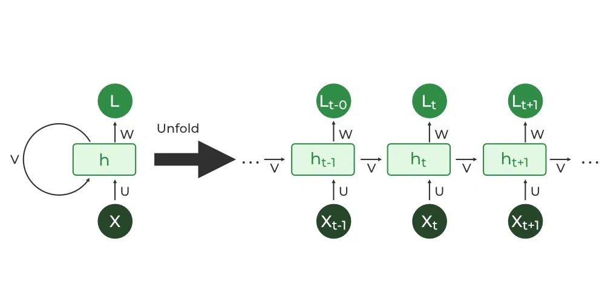

```python
RNN_model = Sequential()
RNN_model.add(Embedding(total_words, 10, input_length=input_len))
RNN_model.add(SimpleRNN(256))
RNN_model.add(Dense(total_words, activation='softmax'))

RNN_model.compile(loss='sparse_categorical_crossentropy', optimizer='adam', metrics = [perplexity])
RNN_history = RNN_model.fit(X_data, y_data, epochs = epochs, callbacks = [earlyStopper])
tracker.add("Simple RNN", RNN_history)
```

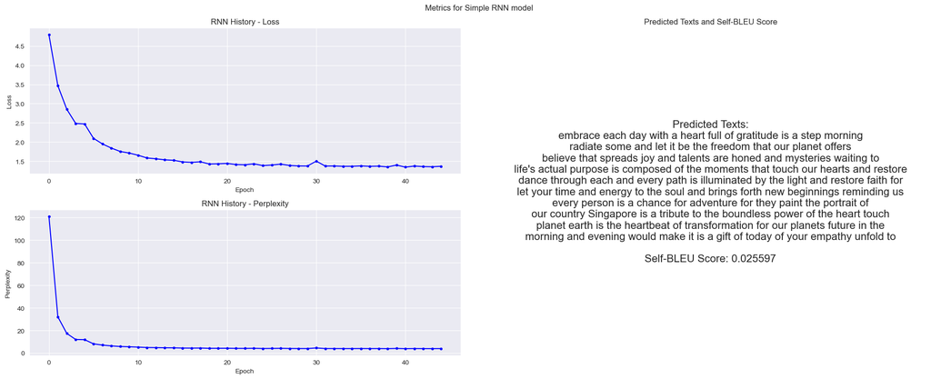

```python
generated_texts, average_self_bleu = full_evaluation(RNN_model, tokenizer, seed_texts, 10, RNN_history, "Simple RNN")
```

LSTM (**L**ong **S**hort-**T**erm **M**emory)

##### LSTMs are a special kind of RNN (Recurrent Neural Network) designed to remember information over a long period. They achieve this through a complex mechanism involving three different "gates":

##### Forget Gate: Decides What to Forget

- Each LSTM cell has a **forget gate** that determines which parts of the cell state (the cell's memory) are no longer relevant and can be discarded.
- This gate examines the **current input** and the **previous hidden state** and outputs numbers between 0 and 1 for each number in the cell state.
  - A value close to **0** means "forget this completely."
  - A value close to **1** means "keep this completely."

##### Input Gate: Decides What to Store

- The **input gate** updates the cell state with new information.
- It consists of two parts:
  - One part decides which values in the cell state to update.
  - Another part creates a vector of new candidate values that could be added to the state.

##### Output Gate: Decides What to Use

- The **output gate** determines the next hidden state, which is used in the current step and passed to the next LSTM cell.
- It considers the **current input**, **previous hidden state**, and **current cell state** to decide what information to use for generating the output.
- The output is typically a filtered version of the cell state, based on what the LSTM has learned as relevant. This output is used for making predictions.

```python
LSTM_model = Sequential()
LSTM_model.add(Embedding(total_words, 10, input_length=input_len))
LSTM_model.add(LSTM(512))
LSTM_model.add(Dense(total_words, activation='softmax'))

LSTM_model.compile(loss='sparse_categorical_crossentropy', optimizer='adam', metrics = [perplexity])
LSTM_history = LSTM_model.fit(X_data, y_data, epochs = epochs, callbacks = [earlyStopper])
tracker.add('Simple LSTM', LSTM_history)
```

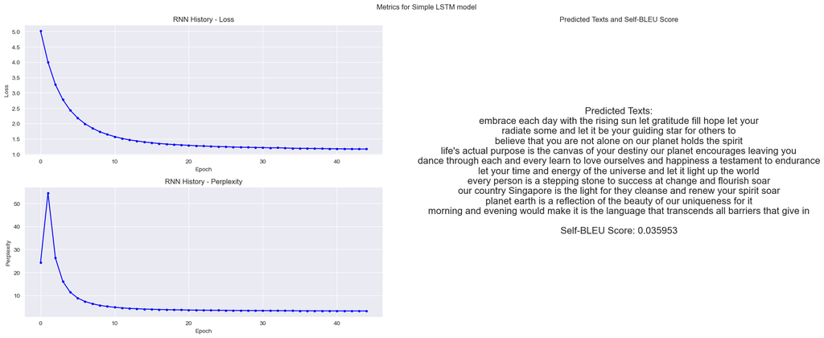

```python
generated_texts, average_self_bleu = full_evaluation(LSTM_model, tokenizer, seed_texts, 10, LSTM_history, "Simple LSTM")
```

GRU (**G**ated **R**ecurrent **U**nit)

##### GRUs are simplified versions of LSTMs. They are based off of LSTMs, but use two gates instead of 3. This makes them simpler and faster compared to LSTMs, although, they mat be as powerful for tasks that require deeper dependencies.

##### Update Gate:

- The update gate helps the GRU decide how much of the past information (from previous time steps) needs to be passed along to the future. It balances between the new input and the information already present in the cell state.
- The update gate is a sigmoid layer that looks at the current input and the previous hidden state.
- It outputs values between 0 and 1 for each component in the hidden state.
- A value close to 1 indicates that most of the previous hidden state should be carried forward, whereas a value close to 0 means it should be ignored in favor of the new input.

##### Reset Gate:

- The reset gate in a GRU helps the network decide how much of the past information to forget. It's crucial for determining how to combine the new input with the previous memory.
- Similar to the update gate, the reset gate is a sigmoid layer that uses the current input and the previous hidden state, producing values between 0 and 1.
- A value close to 0 means it will forget the previous hidden state, and a value close to 1 means it will use this information.

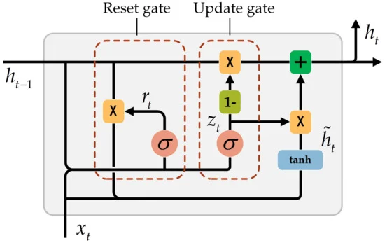

```python
GRU_model = Sequential()
GRU_model.add(Embedding(total_words, 10, input_length=input_len))
GRU_model.add(GRU(256))
GRU_model.add(Dense(total_words, activation='softmax'))

GRU_model.compile(loss='sparse_categorical_crossentropy', optimizer='adam', metrics = [perplexity])
GRU_history = GRU_model.fit(X_data, y_data, epochs = epochs, callbacks = [earlyStopper])
tracker.add('Simple GRU', GRU_history)
```

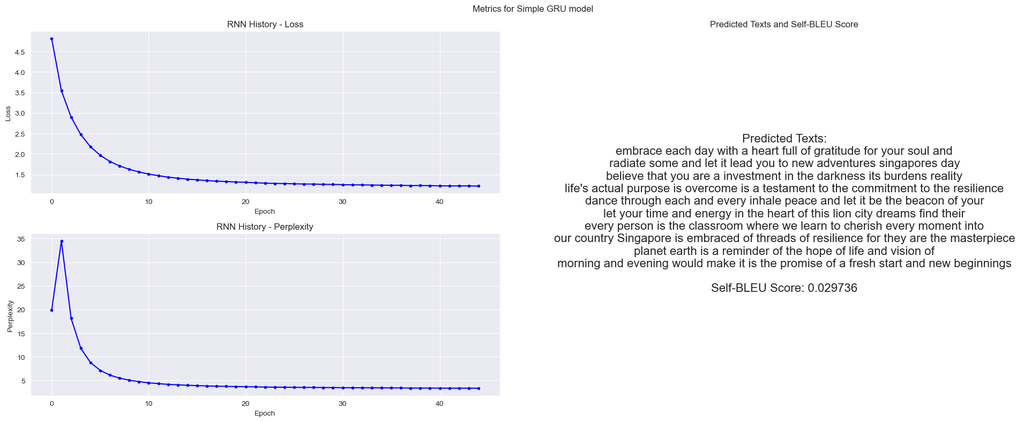

```python
generated_texts, average_self_bleu = full_evaluation(GRU_model, tokenizer, seed_texts, 10, GRU_history, "Simple GRU")
```

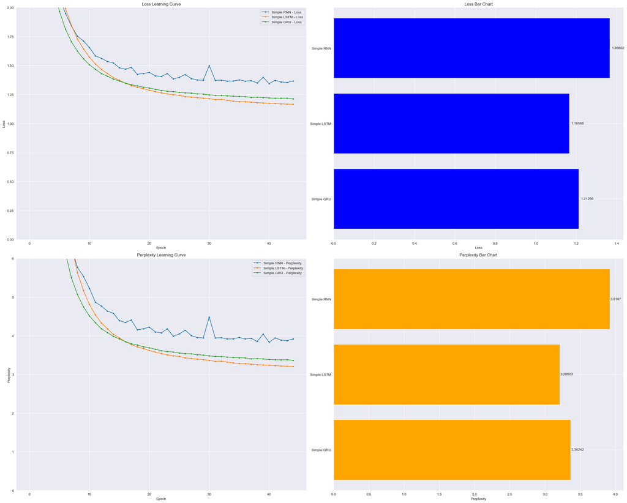

```python
tracker.display()
```

From the above graph, we can see that LSTMs perform the best out of the RNN modules, hence we shall move forward and develop it further for our use.

Bi-Directional RNN

A Bi-Directional Recurrent Neural Network (Bi-Directional RNN) is a variation of the traditional RNN that improves its ability to understand context in a sequence. In a standard RNN, information flows in one direction, from past to future. This means that the RNN processes a sequence in order, from the first element to the last. However, there are many situations where the context of the entire sequence (both past and future elements relative to a certain point) is necessary to make accurate predictions or understandings.

Advantages: The main advantage of Bi-Directional RNNs is their ability to capture context from both directions of the sequence. This often leads to better performance on tasks where understanding the entire sequence is important.

Disadvantages: However, because they process the data in both directions, Bi-Directional RNNs are more computationally expensive than standard RNNs. Additionally, they require access to the entire sequence of data upfront, which means they can't be used in situations where the input data is being streamed in real-time.

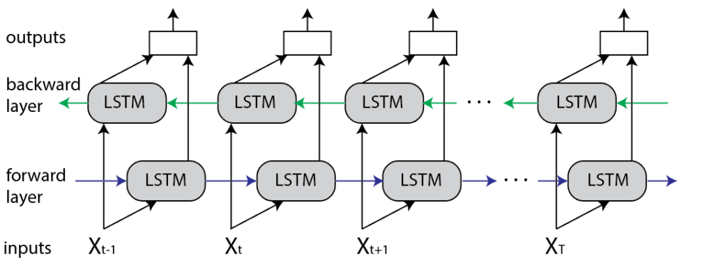

For our use case, we shall use LSTMs as the RNN module, instead of others like RNN and GRUs, as they perform the best out of the other RNN modules.

```python
epochs2 = 125
```

```python
BiLSTM_model = Sequential()
BiLSTM_model.add(Embedding(total_words, 10, input_length=input_len))
BiLSTM_model.add(Bidirectional(LSTM(256)))
BiLSTM_model.add(Dense(total_words, activation='softmax'))

BiLSTM_model.compile(loss='sparse_categorical_crossentropy', optimizer='adam', metrics = [perplexity])
BiLSTM_history = BiLSTM_model.fit(X_data, y_data, epochs = epochs2, callbacks = [earlyStopper])
```

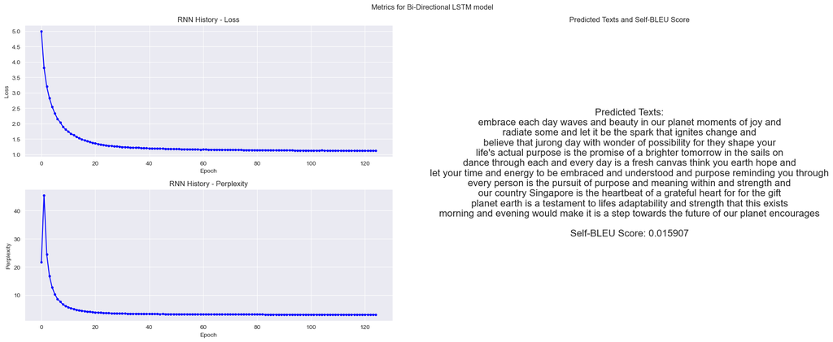

```python
generated_texts, average_self_bleu = full_evaluation(BiLSTM_model, tokenizer, seed_texts, 10, BiLSTM_history, "Bi-Directional LSTM")
tracker.add('Bi-Directional LSTM', BiLSTM_history)
```

Now, in a attempt to further improve the performance of the Bi-Directional RNN, we stack two LSTM layers on top of each other.

```python
BiS_LSTM_model = Sequential()
BiS_LSTM_model.add(Embedding(total_words, 10, input_length=input_len))
BiS_LSTM_model.add(Bidirectional(LSTM(256, return_sequences = True)))
BiS_LSTM_model.add(Bidirectional(LSTM(256)))
BiS_LSTM_model.add(Dense(total_words, activation='softmax'))

BiS_LSTM_model.compile(loss='sparse_categorical_crossentropy', optimizer='adam', metrics = [perplexity])
BiS_LSTM_history = BiS_LSTM_model.fit(X_data, y_data, epochs = epochs2, callbacks = [earlyStopper])
```

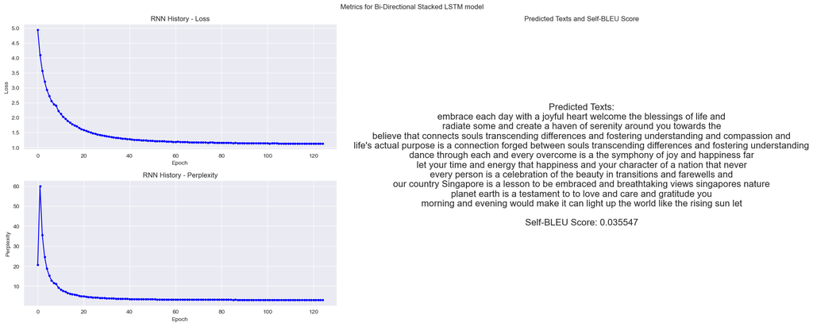

```python
generated_texts, average_self_bleu = full_evaluation(BiS_LSTM_model, tokenizer, seed_texts, 10, BiS_LSTM_history, "Bi-Directional Stacked LSTM")
tracker.add('Bi-Directional Stacked LSTM', BiS_LSTM_history)
```

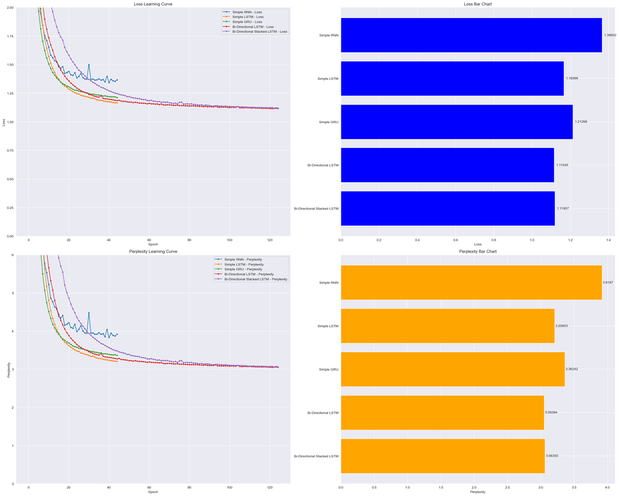

```python
tracker.display()
```

From the above, we can see that Bi-Directional LSTM is better than all the models, out performing the more complicated Bi-Directional Stacked LSTM, while being less computationally intensive to run. We shall select this as the final model, and improve it further

Model Improvement

Enhancing selected architecture

To help us improve the performance of the model further, we shall increase the number of units in the LSTM layer, allowing it to capture more complex relationships in the data, making it more beneficial for tasks such as ours.

However, this more complex model is more prone to overfitting, especially due to the small size of our dataset. To combat this, we shall add a `Dropout` layer to the model to help us avoid overfitting.

```python
improved_Tracker = ModelTracker()
improved_Tracker.add('Bi-Directional LSTM', BiLSTM_history)
```

```python
Bi_LSTMe_model = Sequential()
Bi_LSTMe_model.add(Embedding(total_words, 10, input_length=input_len))
Bi_LSTMe_model.add(Bidirectional(LSTM(512)))
Bi_LSTMe_model.add(Dropout(0.3))
Bi_LSTMe_model.add(Dense(total_words, activation='softmax'))

Bi_LSTMe_model.compile(loss='sparse_categorical_crossentropy', optimizer='adam', metrics = [perplexity])
Bi_LSTMe_history = Bi_LSTMe_model.fit(X_data, y_data, epochs = epochs2, callbacks = [earlyStopper])
```

[figure not shown]

```python
generated_texts, average_self_bleu = full_evaluation(Bi_LSTMe_model, tokenizer, seed_texts, 10, BiS_LSTM_history, "Bi-Directional Enhanced LSTM")
improved_Tracker.add('Bi-Directional Enhanced LSTM', Bi_LSTMe_history)
```

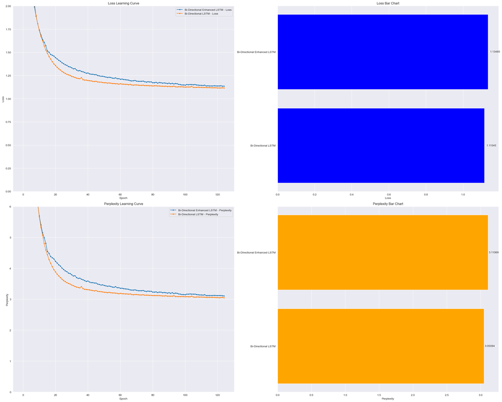

```python
improved_Tracker.display()
```

```python
BiLSTM_model.save_weights("bilstm_weights.h5")
BiLSTM_model.save("bilstm.h5")
```

Now that we have decided on the final model that we want to use, we shall move on to hypertune the model.

Hypertuning

```python
import gc
earlyStopper = EarlyStopping(monitor='loss', patience=10)

def model_hypertuner(optimizers, models, names, batch_sizes, X_data, y_data):
    i = 0
    for optimizer in optimizers:
        for batch_size in batch_sizes:
            clear_output(wait=True)
            print(f"Training {names[i]} with batch size {batch_size}")
            models[i].compile(optimizer=optimizer, loss="sparse_categorical_crossentropy", metrics=[perplexity])
            history = models[i].fit(X_data, y_data, epochs=20, batch_size=batch_size, callbacks=[earlyStopper])
            improved_Tracker.add(names[i], history)
            gc.collect()
            i += 1
```

```python
from IPython.display import clear_output
from tensorflow.keras.optimizers import Adam, SGD
from tensorflow.keras.optimizers.experimental import AdamW
from tensorflow.keras.models import load_model
import tensorflow_addons as tfa

optimizer_list = [
    Adam(),
    SGD(learning_rate=0.005),
    SGD(learning_rate=0.0002),
    SGD(),
    Adam(learning_rate = 0.005),
    Adam(learning_rate = 0.0002),
]

batch_list = [16, 32, 64]

name_list = [
    "Adam_16", "Adam_32", "Adam_64", "SGD_0005_16", "SGD_0005_32", "SGD_0005_64", "SGD_0002_16", "SGD_0002_32", "SGD_0002_64", "SGD_16", "SGD_32", "SGD_64", "Adam_0005_16", "Adam_0005_32", "Adam_0005_64", "Adam_00002_16", "Adam_00002_32", "Adam_00002_64"
]


loaded_models = [load_model('bilstm.h5') for _ in name_list]
model_hypertuner(optimizer_list, loaded_models, name_list, batch_list, X_data, y_data)
```

```
Training Adam_00002_64 with batch size 64
```

[figure not shown]

```python
improved_Tracker.display()
```

From the above, we can see that the model using the SGD optimizer, with a learning rate of 0.005, and a batch size of 16 has the best performance when it comes to metrics. We shall now see if the texts generated makes sense, and use it as the final model if we can.

Final Evaluation

```python
final_model = loaded_models[3]
```

```python
def predict_next_words(model, tokenizer, seed_text, n_words):
    for _ in range(n_words):
        token_list = tokenizer.texts_to_sequences([seed_text])[0]
        token_list = pad_sequences([token_list], maxlen=max_sequence_len-1, padding='pre')
        probabilities = model.predict(token_list, verbose=0)[0]
        chosen_word_index = np.random.choice(range(total_words), p=probabilities)
        output_word = ""
        for word, index in tokenizer.word_index.items():
            if index == chosen_word_index:
                output_word = word
                break
        seed_text += " " + output_word
    return seed_text
```

```python
seed_texts = ['embrace each day', 'radiate some',  'believe that',  "life's actual purpose is",  'dance through each and every', 'let your time and energy', 'every person is', 'our country Singapore is', 'planet earth is', 'morning and evening would make it']
```

Evaluating generated text for model using SGD, learning rate of 0.005, batch size of 16.

```python
for i in range(3):
    generated_texts = []
    for seed in seed_texts:
        texts = predict_next_words(final_model, tokenizer, seed, 10)
        generated_texts.append(texts)
        print(texts)
    print(self_bleu(generated_texts, tokenizer))
    print("\n\n")
```

```
embrace each day with a heart full of gratitude for the stars they
radiate some and let it lead you to your passions and strength
believe that by your way to success and life and let it
life's actual purpose is a promise of warmth and compassion for it has the
dance through each and every step dreams reach for the stars they hold the reminder
let your time and energy with you unstoppable a step towards dreams parks tranquility to
every person is untold with the vitality of kindness and joy and joy
our country Singapore is the heartbeat of love let kindness lights your way on
planet earth is a reflection of the sea of life and species inspire
morning and evening would make it is the key to a legacy of love you grandeur
0.021052545181509764



embrace each day is a canvas inhale peace and reality a encounter worth
radiate some and let it lead you to your passions and strength
believe that by the way to success and life for you planet
life's actual purpose is the strength to overcome any challenge quiet to the southern
dance through each and every step heart and dreams take creating they has the canvas
let your time and energy for you of a inspiration for love for your potential
every person is the essence of true connection and myriad marine species brings
our country Singapore is the heartbeat of our existence embrace it unfold in the
planet earth is a testament to the beauty and richness that meaningful connections
morning and evening would make it is the heartbeat of humanity change and let it be
0.02815319002801616



embrace each day with a heart at the universe to the future of
radiate some for it is the foundation of a joyful heart for
believe that and life and stability this morning offers the promise of
life's actual purpose is a reminder of the earths lifegiving embrace it has the
dance through each and every step dreams reach for the stars they hold the gift
let your time and energy for you of happiness and contentment reside within and new
every person is a chapter in your story for they to the treasure
our country Singapore is the forgiveness for they hold the stories of strength and
planet earth is a classroom where we learn to protect the treasures of
morning and evening would make it is the greatest gift you can happiness aspirations and success
0.03057226168992883
```

Evaluating generated text for model using Adam, learning rate of 0.001, batch size of 16.

We select this model to compare against the best performer instead of the worst 3, as it's curves show that it has hit a plateau in terms of learning, while the curves from the Adam(learning_rate = 0.005) models show that they need more time to learn.

```python
for i in range(3):
    generated_texts = []
    for seed in seed_texts:
        texts = predict_next_words(loaded_models[0], tokenizer, seed, 10)
        generated_texts.append(texts)
        print(texts)
    print(self_bleu(generated_texts, tokenizer))
    print("\n\n")
```

```
embrace each day with a heart full of gratitude for it is the
radiate some for it is the melody of a soul from the
believe that by the transformation that our planet encourages and dreams are
life's actual purpose is your true self shine for new beginnings the day with
dance through each and every day is a fresh canvas for new opportunities for the
let your time and energy will be a beacon of joy for others go a
every person is a gift a reminder of the soul a reminder of
our country Singapore is a sanctuary of your destiny paint it knows intention and
planet earth is a testament to your character of change for they hold
morning and evening would make it is the greatest gift you is your lungs they brings
0.030142300113249757



embrace each day waves to the resilience of our inner wisdom and strength
radiate some and let it be the foundation of your greatness that
believe that in its diversity is its strength and its a song
life's actual purpose is the strength for others a reminder that you are capable
dance through each and every day is a fresh canvas for they paint the day
let your time and energy will be a beacon of joy for others go in
every person is a marvel in the treasury of progress and and forth
our country Singapore is it with vibrant strokes of kindness is a reminder of
planet earth is a testament to your indomitable spirit and strength and others
morning and evening would make it knows no limits a joyful heart of the journey weve
0.01806184761906732



embrace each day on the canvas can rich and boundless power of the
radiate some and let it be the source of innovation and transformation
believe that with the world around you of joy with strength and
life's actual purpose is of our planet find the way forward to alive and
dance through each and every step holds its change and reality in our ebb and
let your time and energy for others of the preciousness of life on species in
every person is a reminder of the opportunities in the beauty in the
our country Singapore is it with the world becomes your canvas skies let love
planet earth is a testament to your inner strength and resilience a reminder
morning and evening would make it is the greatest gift that others to your life and
0.027869861380314758
```

Comparing the texts, we shall pick the SGD(learning_rate = 0.005), batch size 16 model, as it has the best metrics, while producing text on the same level of the Adam(learning_rate = 0.001), batch size 16 model.

We shall select that model as the final one, and save it's weights.

```python
final_model.save_weights("final_model_weights.h5")
```

Conclusions

This exercise was a interesting one, providing us a insight into how a RNN tool can be developed.

There were several things that I would like to have attempted for this assignment, such as Attention to further enhance the "memory" of our LSTM models, as well as carrying our character based predictions, along with longer predictions to test the robustness of the model. However, I could not attempt it for this assignment due to several limitations.

Despite this, it was quite interesting attempting to create a next-word predictor, and we can see the fruits of our labour.